# HW3 - 2

Renjie Liu

2/14/2021

1. Split sample into two random samples of sizes 70% and 30%.

```r
library(ggplot2)
library(mlbench)
library(dplyr)
data("BostonHousing")
set.seed(1234)

train_index <- sample(seq_len(nrow(BostonHousing)),size = floor(0.7*nrow(BostonHousing)))

train <- BostonHousing[train_index,]

test <- BostonHousing[-train_index,]
```

2.Perform principal components of numeric variables from the Boston Housing Data on training sample.

```r
train <- scale(train[,c(-4,-9)])

test <- scale(test[,c(-4,-9)])

pca_train <- princomp(train)
```

3.Generate Scree Plots and select number of components you would retain.

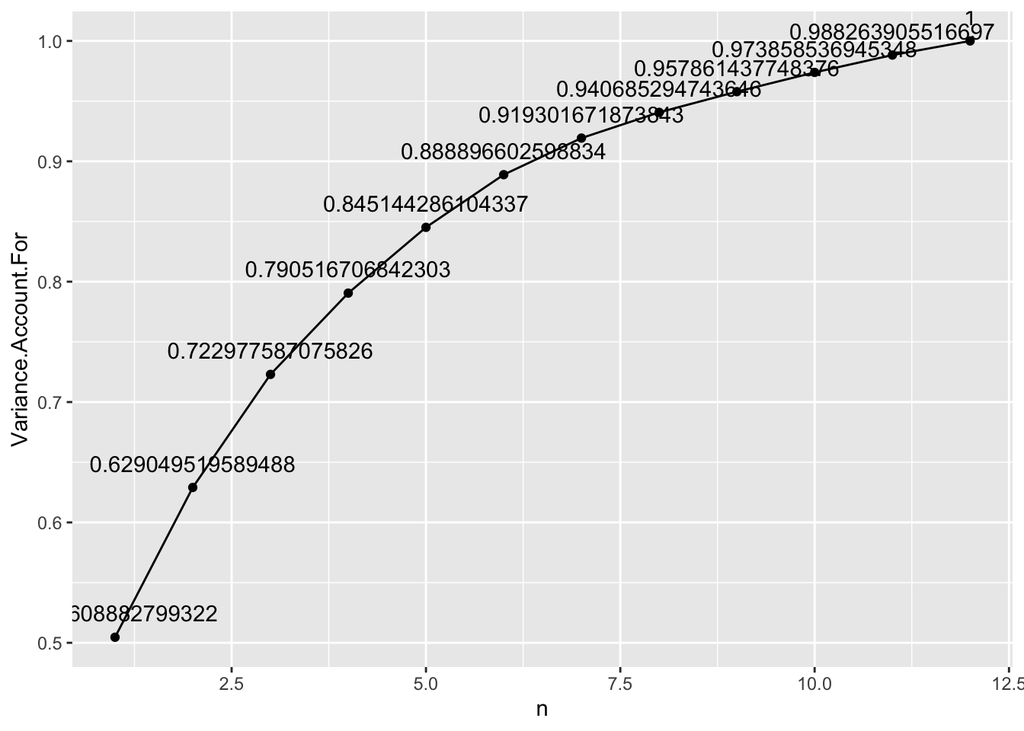

```r
VAF = cumsum(pca_train$sdev^2/sum(pca_train$sdev^2))

data.frame(n = 1:length(VAF),Variance.Account.For = VAF) %>%
  ggplot(aes(x=n, y=Variance.Account.For)) +
  geom_line() +
  geom_point()+
  geom_text(aes(label=VAF),vjust = -1)
```

```r
"I will choose 5 componets because the curve is becoming flat after 5 components. 5 components will have a VAF of around 85%"
```

```
## [1] "I will choose 5 componets because the curve is becoming flat after 5 components. 5 components will have a VAF of around 85%"
```

4.Plot Component 1 loadings (x-axis) versus Component 2 loadings (y-axis). Use this plot to interpret and name the Components. Repeat this by plotting Component (1) separately versus all components you decided to retain from Step 3 (Component 3, Component 4 etc). Can you interpret each of the components you decide to retain. In case a component is not interpretable, note that.

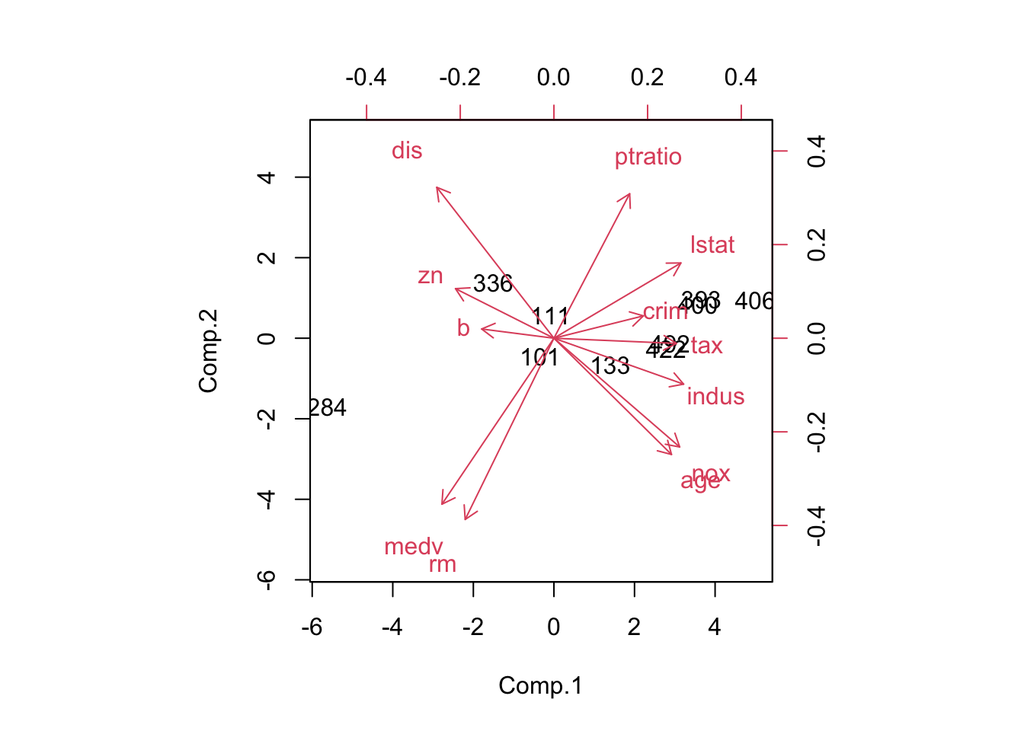

```r
biplot(pca_train$scores[1:10,c(1,2)],pca_train$loadings[,c(1,2)])
```

```r
"Component 1 has the variances of all the predictors. For Component 1 , nox, age, indus, and ptratio have large positive effect on component 1. dis,medv, and rm have large negative effect on component 1. The lower the component 1 the higher the house price. I think component 1 is a good measure of all the information for a house, especially for the house price.

For Component 2, dis, ptratio have very large positive effect on component 1. Medv,age, and nox have very large negative effect on component 2. Component 2 also measures the house price, and also measures the distance of the house."
```

[output not shown]

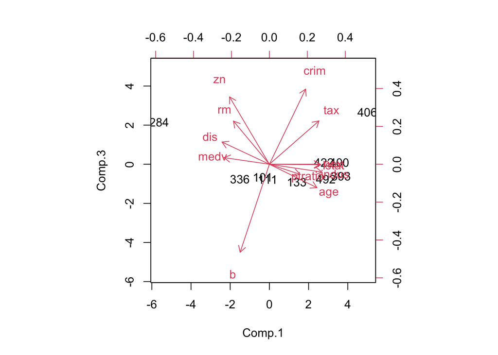

```r
biplot(pca_train$scores[1:10,c(1,3)],pca_train$loadings[,c(1,3)])
```

```r
"component 3 has limited information for the variabes mentioned in component 1 and component 2. However, component 3 is heavily affected by crim, tax, zn, and b. Therefore, I believe that component 3 measures the crime rate for the house."
```

```
## [1] "component 3 has limited information for the variabes mentioned in component 1 and component 2. However, component 3 is heavily affected by crim, tax, zn, and b. Therefore, I believe that component 3 measures the crime rate for the house."
```

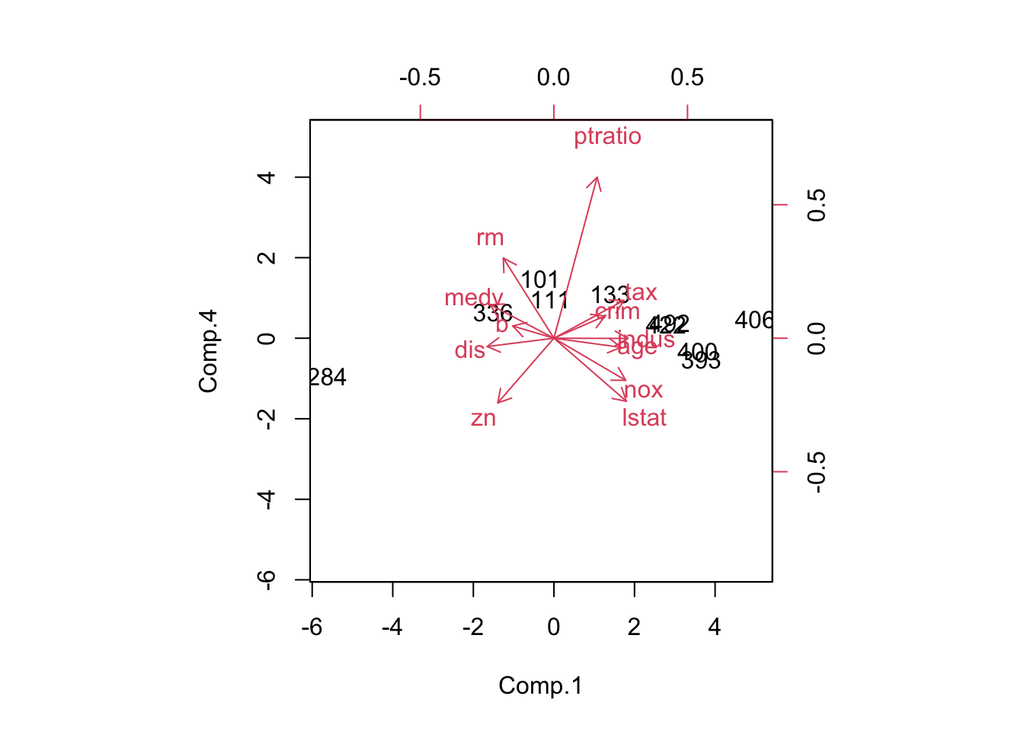

```r
biplot(pca_train$scores[1:10,c(1,4)],pca_train$loadings[,c(1,4)])
```

component 4 has limited information for variabels in component 1 ,2,3. Component 4 is largely impacted by ptratio. The ptratio measures the pupil-teacher ratio by town. Therefore, i think component 4 measures the educatioal quality for the house’s town.

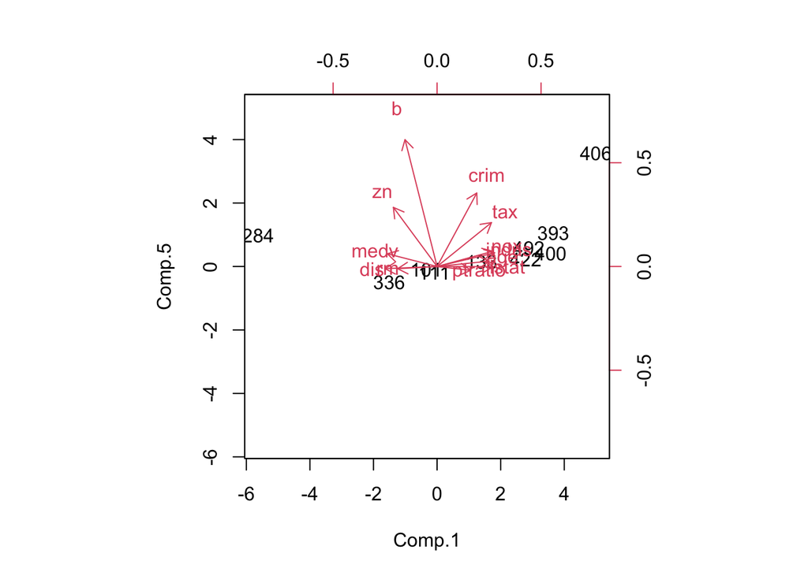

```r
biplot(pca_train$scores[1:10,c(1,5)],pca_train$loadings[,c(1,5)])
```